[View on GitHub](https://github.com/obenshaindw/coursera-practical-machine-learning)

# Coursera-practical-machine-learning

## Repository for submission of Practical Machine Learning assignment

[Download this project as a .zip file](https://github.com/obenshaindw/coursera-practical-machine-learning/zipball/master) [Download this project as a tar.gz file](https://github.com/obenshaindw/coursera-practical-machine-learning/tarball/master)

[Download R Markdown for this project .Rmd file](https://github.com/obenshaindw/coursera-practical-machine-learning/blob/gh-pages/resources/Practical%20Machine%20Learning%20-%20Human%20Activity%20Recognition.Rmd)

# Practical Machine Learning - Human Activity Recognition

David Obenshain

March 20, 2016

## Overview

Using data acquired by wearable activity monitors, we will train a model to predict the type of exercise being performed. The Human Activity Recognition (HAR) dataset from http://groupware.les.inf.puc-rio.br/har.

Six participants were asked to perform excerises with the dumbell in five different ways: exactly according to the specification (Class A), throwing the elbows to the front (Class B), lifting the dumbbell only halfway (Class C), lowering the dumbbell only halfway (Class D) and throwing the hips to the front (Class E). Sensors were placed on the arm, forearm, belt, and dumbell.

## Retreiving and Subsetting the data

[Training](https://d396qusza40orc.cloudfront.net/predmachlearn/pml-training.csv) and [Testing](https://d396qusza40orc.cloudfront.net/predmachlearn/pml-testing.csv) data are being supplied.

Looking at the data we observe entries with #DIV/0! and quite a few blanks in the raw dataset, which will investigate further after we load the dataset.

```r
data <- read.table(file="pml-training.csv", header=TRUE, sep=",", na.strings=c('NA','#DIV/0!'))
dim(data)
```

```
## [1] 19622   160
```

```r
data.subset <- data[colSums(!is.na(data)) == dim(data)[1]]
data.subset <- data.subset[,8:60]
```

## Building the Model

Given mulitple records from each sensor during each activity type we will use cross-validation (CV) to build our test/train dataset.A CV approach ensures every data point gets to be in the test set and k-1 times in the train set, where k is the number of fold, 5 in this case. We will use a random forest to build our model, setting all remaining variables as possilbe predictors of classe, our outcome.

The Random Forest algorithm uses the concept of a classification or decision tree, but creates many trees each using randomly selected predictor variables for each node in the tree. The concept of a 'forest' is that the individual trees vote for the best predictor, and the best tree is built based on those votes.

```r
trCtl <- trainControl(method="cv", number=5)
rf.model <- train(classe ~ ., data=data.subset, method="rf", trControl=trCtl)
```

## Evaluating the Model

Looking at the model we acheive very high accuracy 0.995 from only a few predictors, roll_belt being most important. We also observe low Out of Bound error of 0.41.

```r
print(rf.model)
```

```
## Random Forest
##
## 19622 samples
##    52 predictor
##     5 classes: 'A', 'B', 'C', 'D', 'E'
##
## No pre-processing
## Resampling: Cross-Validated (5 fold)
## Summary of sample sizes: 15698, 15696, 15698, 15699, 15697
## Resampling results across tuning parameters:
##
##   mtry  Accuracy   Kappa      Accuracy SD  Kappa SD
##    2    0.9948019  0.9934245  0.002018831  0.002553830
##   27    0.9944959  0.9930375  0.001597751  0.002021799
##   52    0.9889920  0.9860740  0.002857038  0.003615578
##
## Accuracy was used to select the optimal model using  the largest value.
## The final value used for the model was mtry = 2.
```

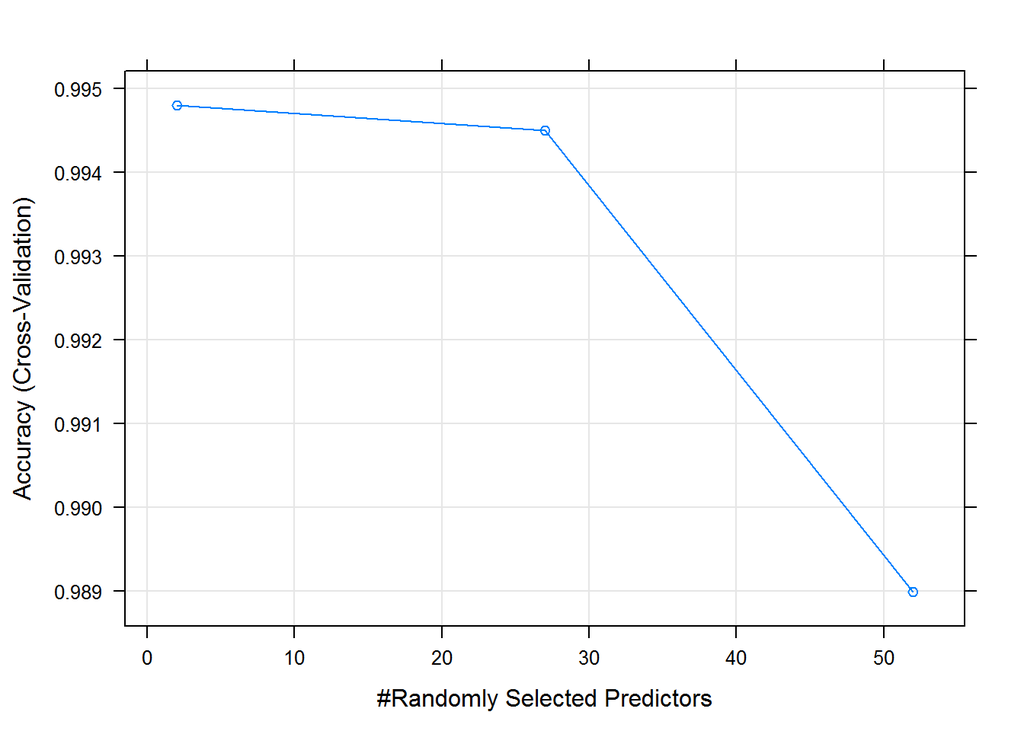

```r
plot(rf.model)
```

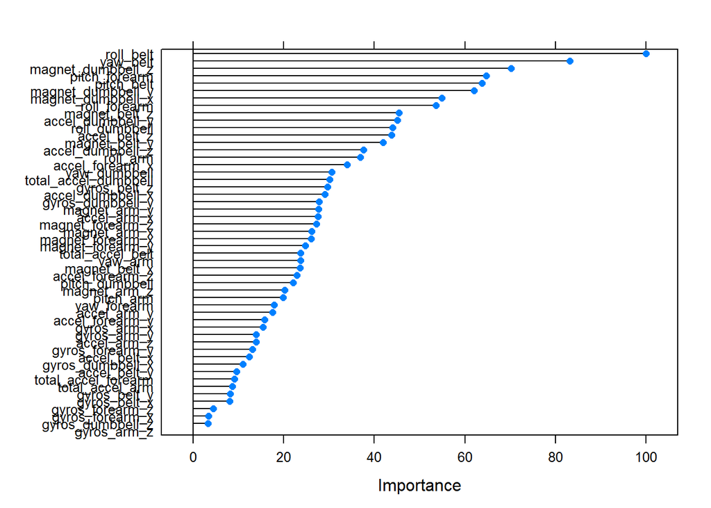

```r
plot(varImp(rf.model))
```

```r
print(rf.model$finalModel)
```

```
##
## Call:
##  randomForest(x = x, y = y, mtry = param$mtry)
##                Type of random forest: classification
##                      Number of trees: 500
## No. of variables tried at each split: 2
##
##         OOB estimate of  error rate: 0.41%
## Confusion matrix:
##      A    B    C    D    E  class.error
## A 5577    3    0    0    0 0.0005376344
## B   10 3783    4    0    0 0.0036871214
## C    0   18 3402    2    0 0.0058445354
## D    0    0   34 3179    3 0.0115049751
## E    0    0    0    6 3601 0.0016634322
```

## Predicting using the Model

Now we use the model to predict the classe of the test data supplied for this exercise.

```r
testing <- read.table(file='pml-testing.csv', header=TRUE, sep=",", na.strings=c('NA','#DIV/0!') )
rf.pred <- predict(rf.model, testing)
```

For the 20 test cases, our model predicts the following for the classe variable: B, A, B, A, A, E, D, B, A, A, B, C, B, A, E, E, A, B, B, B